# Modelo metapoblacional para simular el manejo de COVID19 en Chile

16/04, 2020

## Generalidades del modelo

- Modelo de Arenas *et al.* 2020
- Modelo SEAIHRM
- Estructurado por edad (0-25, 25-65, 65+)
- Realizado a nivel de Comuna (todas las comunas en forma simultanea)
- Permite manejo a nivel comunal (Cada comuna puede tener medidas de forma asincrónica)

## Flujo del modelo

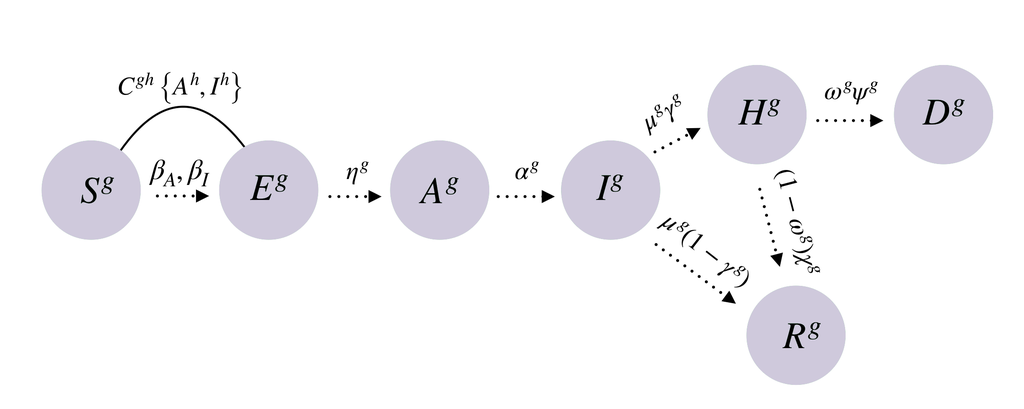

## Con conexiones espaciales

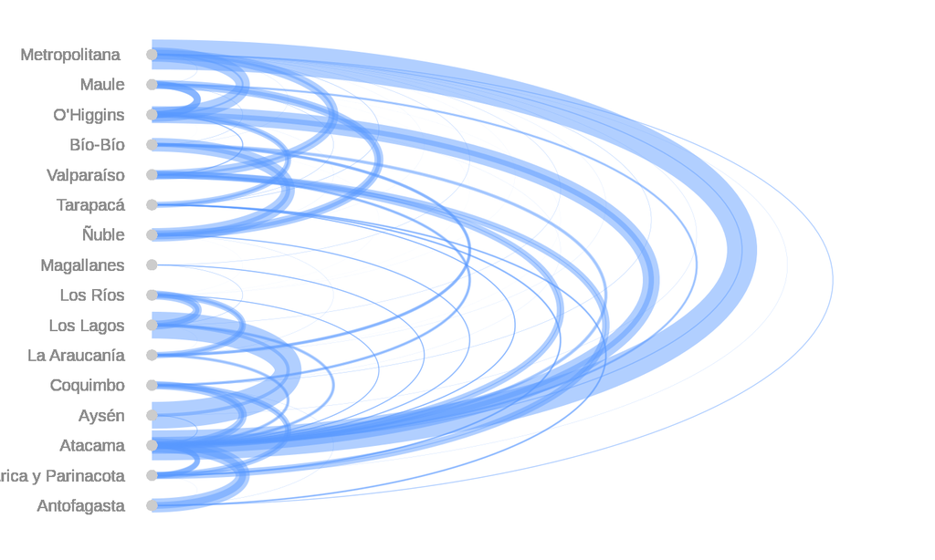

## Para comunas

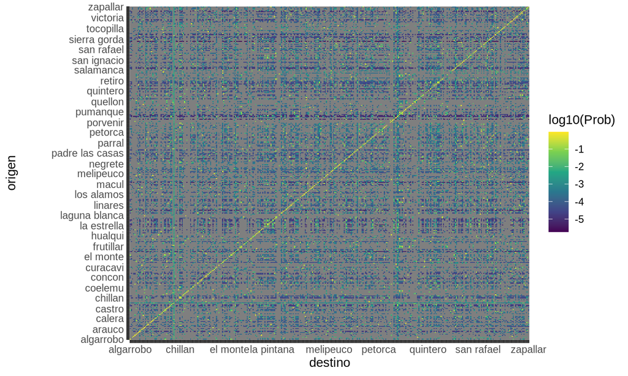

## Modelo

\[\rho_{i(t+1)}^{S,g} = \rho_{i(t)}^{S,g}(1 - {\color{red}{K_{0(t)}} }\times CH_{i(t)})(1-\Pi_{i(t)}^g) \]

\[\rho_{i(t+1)}^{E,g} = \rho_{i(t)}^{E,g}(1 - {\color{red}{K_{0(t)}} }\times CH_{i(t)})\Pi_{i(t)}^g + (1- \eta^g)\rho_{i(t)}^{E,g}\]

\[\rho_i^{A,g}(t+1) = \eta^g\rho_i^{E,g}(t)+(1-\alpha^g)\times \rho_i^{A,g}(t)\]

\[\rho_i^{H,g}(t+1) = \mu^g\times \gamma^g \times \rho_i^{I,g}(t) + \omega^g(1 - \psi^g)\times \rho_i^{H,g}(t) + (1- \omega^g)(1-\chi^g)\rho_i^{H,g}(t)\]

\[\rho_i^{D,g}(t+1) = \omega^g \times \psi^g \times \rho_i^{H,g}(t) + \rho_i^{D,g}(t)\] \[\rho_i^{R,g}(t+1) = \mu^g (1 -\gamma^g)\times \rho_i^{I,g}(t) + (1 - \omega^g) \chi^g \times \rho_i^{H,g}(t) + \rho_i^{R,g}(t)\]

- Cuando \(K_{0i(t)}\) = 0 no hay cuarentena, si es 1 es cuarentena absoluta
- \(CH_{i(t)}\) es la probabilidad de que nadie en una casa este contagiado (\(\sigma\) = 3.1)

## Simulaciones recientes

## Manejo adaptativo vs Lockdown

- Desde el 30 de Marzo
- Cuarentena adaptativa
- Cuarentena Nacional por 15 días

## Días en cuarentena

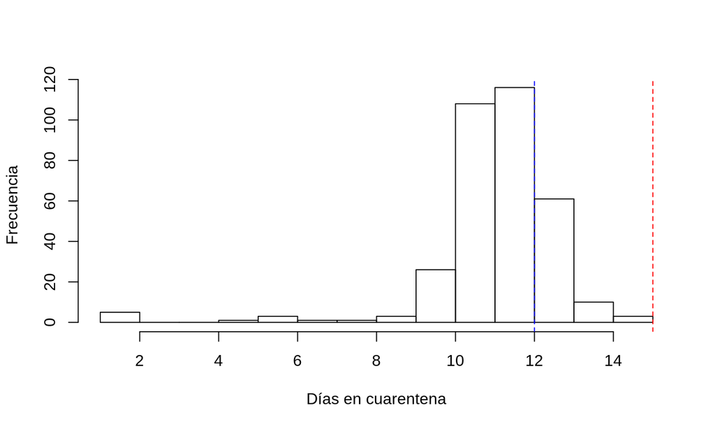

## UCI

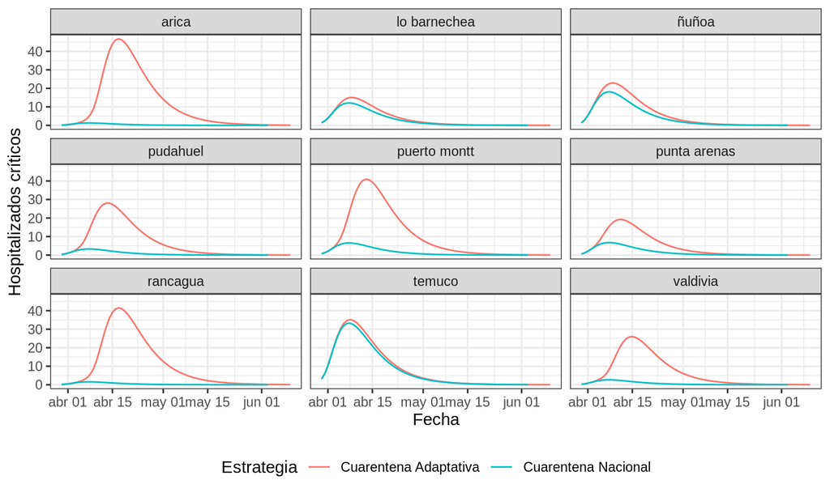

## Fallecidos

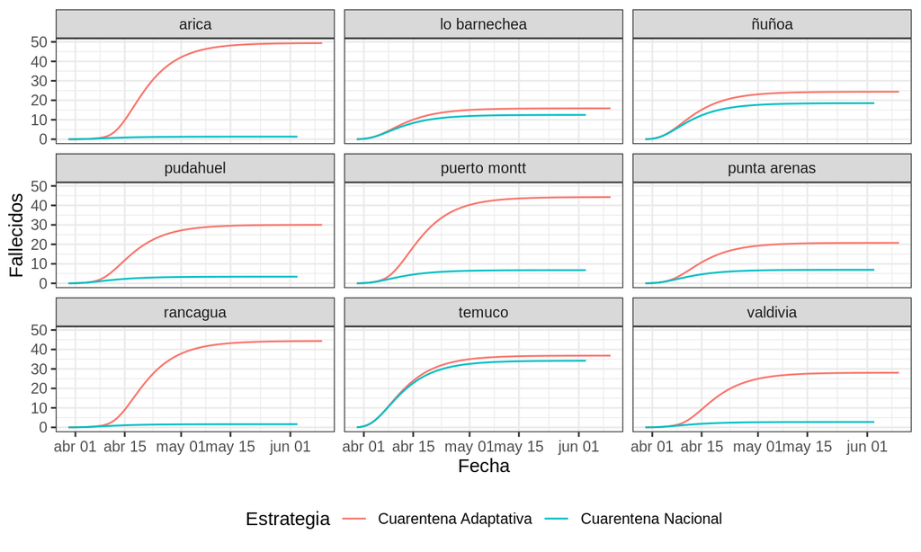

[Mas Comunas](https://www.ecoinformatica.net/COVID19.html)

## Nacional UCI

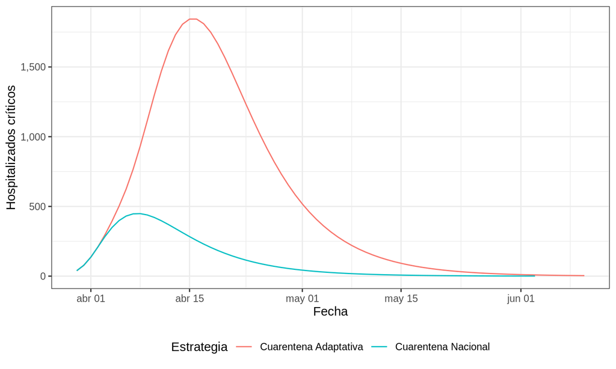

## Nacional Fallecidos

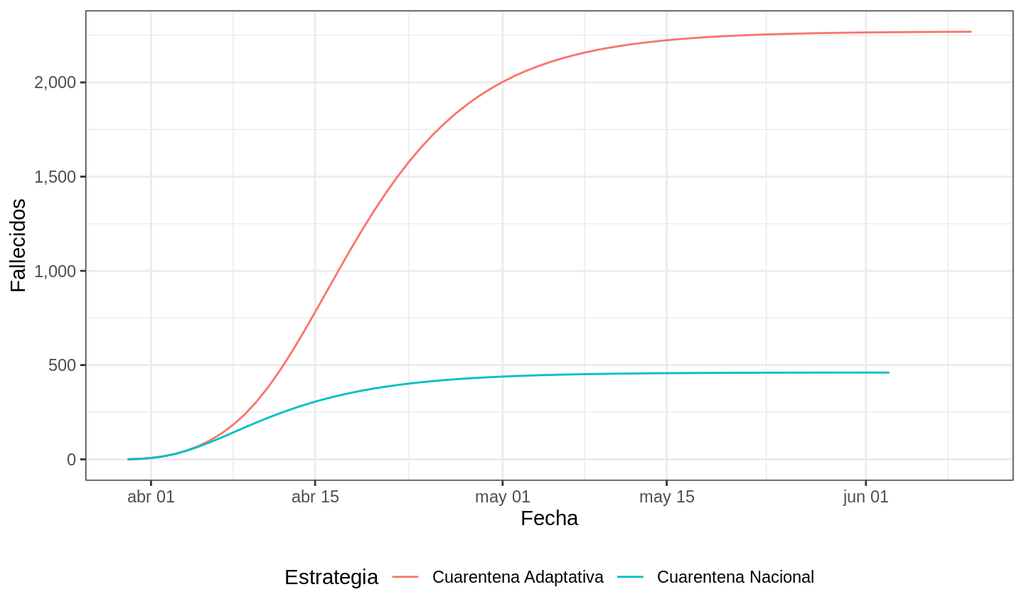

## Nacional Acumulado

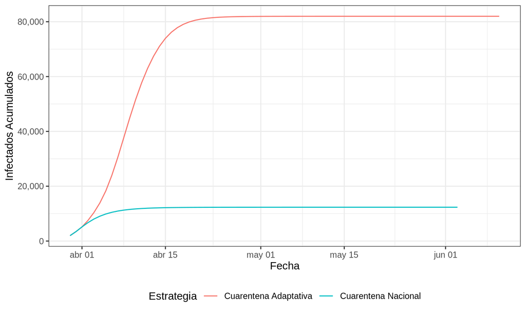

## Tiempo de cuarentena nacional

- Empezando el modelo el 10 de abril

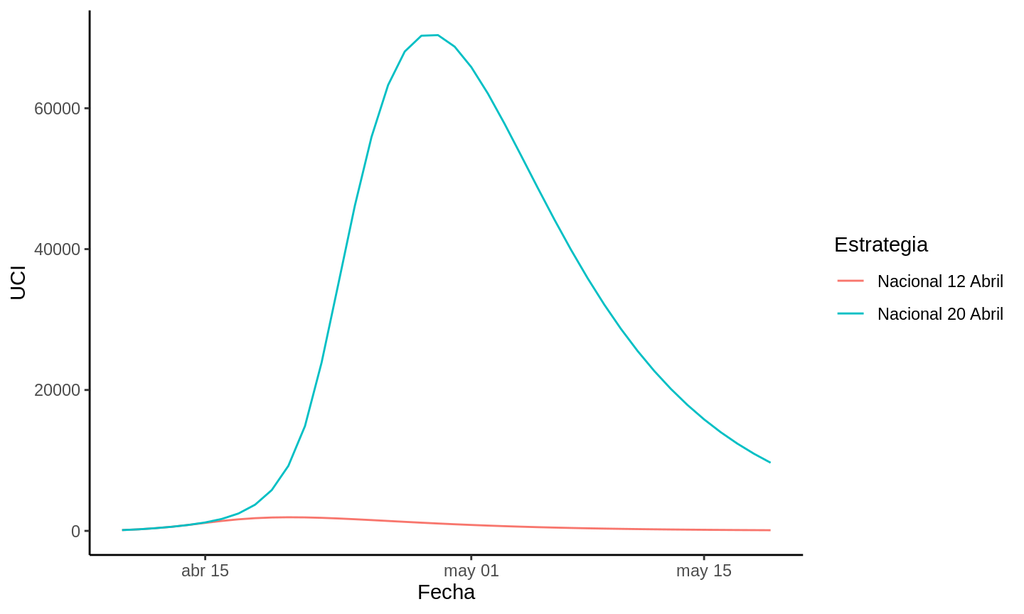

## Recomendaciones y conclusiones

## Recomendaciones

- Debiera instaurarse una cuarentena nacional
- Resultados preliminares dicen que cuanto mas temprano empieza la cuarentena nacional es mejor
- Esto beneficiará más a las comunas que no han tenido cuarentenas
- Antes del peak la probabilidad de que que haya no hayan infectados, expuestos o asintomáticos en una casa bajan en el tiempo \(CH_{i(t)}\)

## Necesidades

- Transparencia en los datos por comuna
- Entrega de datos de Recuperados, Fallecidos, etc por comuna
- En un mundo ideal, generación de API para acceder a datos

## Recursos

- Repositorio [github](https://github.com/derek-corcoran-barrios/Covid19_Chile_Age) con los modelos y bases de datos
- Visualizador [de datos](https://www.ecoinformatica.net/COVID19.html)